# Machine Learning Models

A Kannankeril

2/22/2021

[Github Repo](https://github.com/artinarayan/MachineLearning)

## Overview

Using devices such as Jawbone Up, Nike FuelBand, and Fitbit it is now possible to collect a large amount of data about personal activity relatively inexpensively. One thing that people regularly do is quantify how much of a particular activity they do, but they rarely quantify how well they do it. The goal of this project is to use the data (http://groupware.les.inf.puc-rio.br/har) from accelerometers on the belt, forearm, arm, and dumbell of 6 participants and to predict the manner in which they did the exercise. Following steps will be performed for prediction:

- cleaning datasets of irrelevant columns
- Splitting the training data set into two partitions
- Running 3 different training models
- Assessing models to find the best fit
- Predicting the outcome using the best model

### 1. DATA LOADING AND CLEANING

In this step, we tidy the data by removing all columns with NAs from both the training and test data. Columns 1 to 7 are removed from both datasets which are not relevant features.

```r
#load data
training <- read.csv('./pml-training.csv',header=T,
                     na.strings=c("NA","#DIV/0!", "") )
validation <- read.csv('./pml-testing.csv', header=T,
                    na.strings=c("NA","#DIV/0!", ""))

#clean data and remove irrelevant columns
zero_colnames <- sapply(names(validation), function(x) all(is.na(validation[,x])==TRUE))
non_zero_colnames <- names(zero_colnames)[zero_colnames==FALSE]

non_zero_colnames<- non_zero_colnames[-(1:7)]
non_zero_colnames <- non_zero_colnames[1:(length(non_zero_colnames)-1)]

training<-training[,c(non_zero_colnames,"classe")]
validation<-validation[,c(non_zero_colnames,"problem_id")]
```

### 2. DATA PARTITIONING

The training data is split into training and testing partitions (70/30 ratio). File “pml-testing.csv” is used for final prediction. Cross validation is used within the training partition to improve the model fit and then an out-of-sample test is done with the testing partition.

```r
set.seed(12345)
inTrain <- createDataPartition(training$classe, p=0.70, list=FALSE)
TrainSet <- training[inTrain, ]
TestSet <- training[-inTrain, ]
```

### 3. CROSS VALIDATION AND MODEL BUILDING

Three different model algorithms are used and then reviewed to see which of them provides the best out-of-sample accuracy. Cross validation has been done for each model with K = 3. The three model types used to test are:

- Decision trees (rpart)
- Gradient boosting trees (gbm)
- Random forest (rf)

**Cross Validation**

```r
trControl <- trainControl(method="cv", number = 3,
                          allowParallel = TRUE)
```

**Decision Trees/CART**

```r
# Decision Trees
model.dt <- train(classe ~ ., data = TrainSet, method = "rpart",
                  trControl = trControl)
predict.dt <- predict(model.dt, newdata = TestSet)
cm.dt<-confusionMatrix(predict.dt, as.factor(TestSet$classe))
```

**Random Forests**

```r
model.rf <- train(classe ~ ., data=TrainSet, method="rf",
                          trControl=trControl)
predict.rf <- predict(model.rf, newdata = TestSet)
cm.rf<-confusionMatrix(predict.rf, as.factor(TestSet$classe))
```

**Gradient Boosted Machines**

```r
model.gbm <- train(classe ~ ., data = TrainSet, method = "gbm",
                   trControl = trControl, verbose = FALSE)
predict.gbm <- predict(model.gbm, newdata = TestSet)
cm.gbm<-confusionMatrix(predict.gbm, as.factor(TestSet$classe))
```

### 4. MODEL ASSESSMENT

```r
Results <- data.frame(
      Model = c('CART', 'GBM', 'RF'),
      Accuracy = rbind(cm.dt$overall[1], cm.gbm$overall[1], cm.rf$overall[1]),
      Kappa = rbind(cm.dt$overall[2], cm.gbm$overall[2], cm.rf$overall[2]),
      AccuracyLower = rbind(cm.dt$overall[3], cm.gbm$overall[3],
                            cm.rf$overall[3]),
      AccuracyUpper = rbind(cm.dt$overall[4], cm.gbm$overall[4],
                            cm.rf$overall[4])


)
print(Results)
```

```
##   Model  Accuracy     Kappa AccuracyLower AccuracyUpper
## 1  CART 0.4895497 0.3323704     0.4767009     0.5024089
## 2   GBM 0.9590484 0.9481853     0.9536676     0.9639679
## 3    RF 0.9949023 0.9935514     0.9927306     0.9965580
```

After review of 3 model fits and out-of-sample results, it looks like both gradient boosting and random forests outperform the CART model, with random forest being slightly more accurate (*99%*). Random Forest model will therefore be used for prediction. The confusion matrix for the random forest model is below.

```
##           Reference
## Prediction    A    B    C    D    E
##          A 1673    6    0    0    0
##          B    1 1130    5    0    0
##          C    0    3 1018    8    2
##          D    0    0    3  955    1
##          E    0    0    0    1 1079
```

The random forest model with highest accuracy includes the following 5 features as the most important for predicting the exercise.

|  | Overall |
| --- | --- |
| roll_belt | 100.00 |
| pitch_forearm | 58.22 |
| yaw_belt | 54.50 |
| magnet_dumbbell_y | 44.66 |
| roll_forearm | 43.47 |

### 5. PREDICTION

Finally, applied Random Forest model to the validation data sample (*pml-testing.csv*) to predict a classe for each of the 20 observations.

```r
predictTEST <- predict(model.rf, newdata=validation)
predictTEST
```

```
##  [1] B A B A A E D B A A B C B A E E A B B B
## Levels: A B C D E
```

### APPENDIX

[figure not shown]

```r
fancyRpartPlot(model.dt$finalModel)
```

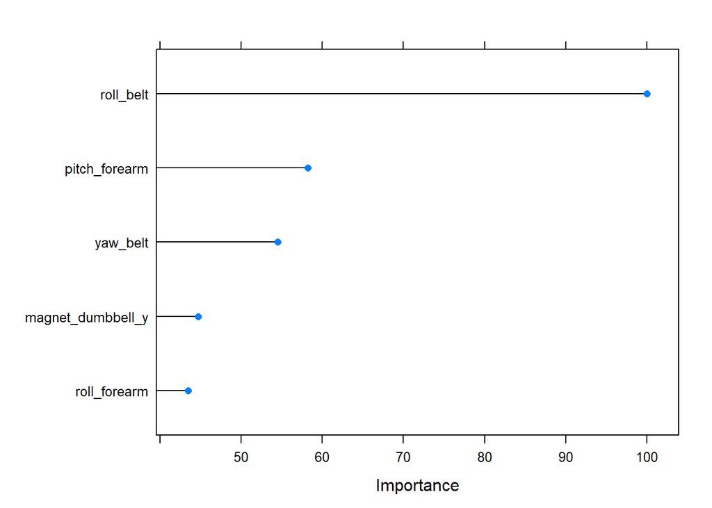

```r
plot(varImp(model.rf), top = 5)
```